# The Evolution of Popular Music over Recent Years

### By Noah Griff, Timmy Trapaidze, and Christian Tonti

[figure not shown]

1. Introduction
   - Useful Resources
2. Data Collection and Cleaning
3. Analysis
4. Insights

## Introduction

Over the years, music has become an increasingly large part of our daily lives. With each technological development, from public radio and cassette tapes to music streaming services and fully wireless earbuds, we have had more and more ways to listen to the songs we love. While a form of cultural and personal expression, popular music also provides a common ground on which people can connect. When a song comes on at an event or party that everybody knows the words to, people sing along, have fun, and have a great time. So we started thinking: while music-listening technology has changed over the years, how has what the general population considers enjoyable evolved? What attributes of a song make it popular, and is it that different a couple decades ago?

Luckily for us, a company has been keeping track of the most popular songs since the latter half of the 20th century. Starting in August of 1958, Billboard has been publishing the Hot 100 songs every week, year and decade, allowing us to get a snapshot of what popular music has looked like over time.

In this project, we will be using Billboard's yearly Hot 100 charts from 1971 to present along with Spotify's Web API in order to conduct analysis on the evolution of popular music in recent years. Spotify's API has an endpoint called audio-analysis, which returns analytical information about a song, such as its tempo, key, danceability, and energy. Using all of this information, we will analyze if any of these features have changed over time, as well as if there is a correlation between them and the song's rank within the chart.

### Useful Resources

Here is a list of some useful, helpful, or interesting resources related to our work:

- [The creation, rise, and rule of Billboard's Hot 100 - NPR](https://www.npr.org/sections/therecord/2013/08/16/207879695/how-the-hot-100-became-americas-hit-barometer)
- [Why music is getting louder - Curiosity.com](https://curiosity.com/topics/why-music-is-getting-louder-curiosity/)
- [Why music is getting shorter - Quartz](https://qz.com/quartzy/1438412/the-reason-why-your-favorite-pop-songs-are-getting-shorter/)
- [Research paper on the evolution of popular music](https://doi.org/10.1098/rsos.150081)
- [Spotify Web API Reference](https://developer.spotify.com/documentation/web-api/reference/)
  - [Audio analysis endpoint](https://developer.spotify.com/documentation/web-api/reference/tracks/get-audio-analysis/)

For this project, we will be using Python 3 along with the following libraries:

- [spotipy](https://spotipy.readthedocs.io/en/latest/#) to efficiently query the Spotify Web API with Python
- [urllib.request](https://docs.python.org/3/library/urllib.request.html) to get the HTML from the websites which have the Billboard Hot 100 charts
- [pandas](https://pandas.pydata.org/pandas-docs/stable/) to store, organize, and manipulate all of our data using powerful DataFrame objects
- [numpy](https://docs.scipy.org/doc/numpy/reference/index.html) to add NaN values as well as some extra functions
- [seaborn](https://seaborn.pydata.org/) to easily and beautifully visualize our findings
- [matplotlib.pyplot](https://matplotlib.org/3.1.1/api/_as_gen/matplotlib.pyplot.html) to further manipulate the appearance of our graphs

We begin by importing these libraries here:

```python
# install spotipy and WordCloud if not installed
!pip install spotipy
!pip install wordcloud
# imports
from urllib.request import urlopen as uReq
from urllib.request import Request, urlopen
import pandas as pd
import numpy as np
import spotipy
import spotipy.util as util
from wordcloud import WordCloud
from spotipy.oauth2 import SpotifyClientCredentials
import seaborn as sns
import matplotlib.pyplot as plt
from IPython.display import Image
import time
```

## Data Collection and Cleaning

The first thing we must do is to obtain the data we wish to analyze. This includes getting the top 100 songs from every year, finding those songs on Spotify, and then obtaining the audio analysis for each song.

```python
# perform an initial read for 1970 to start off the larger dataframe
page = Request("https://en.wikipedia.org/wiki/Billboard_Year-End_Hot_100_singles_of_1970",headers={'User-Agent': 'Mozilla/5.0'})
html = urlopen(page).read()
wiki = pd.read_html(html)[0]

for i in range(1971,2020):
    #2012 and 2013 just did not want to be scrapable
    if(i != 2012 and i != 2013):
        # create list for year column in the dataframe
        year = [i] * 100
        # open and read the page
        page = Request("https://en.wikipedia.org/wiki/Billboard_Year-End_Hot_100_singles_of_"+str(i),headers={'User-Agent': 'Mozilla/5.0'})
        html = urlopen(page).read()
        # read in the table of songs
        cur = pd.read_html(html)[0]
        # add year column
        cur['year'] = year
        # append to larger dataframe
        wiki = wiki.append(cur,ignore_index=True)
```

```python
wiki.info()
```

```
<class 'pandas.core.frame.DataFrame'>
RangeIndex: 4701 entries, 0 to 4700
Data columns (total 7 columns):
0            0 non-null float64
1            1 non-null object
Artist(s)    4700 non-null object
No.          3200 non-null float64
Title        4700 non-null object
year         4700 non-null float64
№            1500 non-null float64
dtypes: float64(4), object(3)
memory usage: 257.2+ KB
```

```python
# create empty list for rank column
rank = []
# replace NaNs with 0
wiki = wiki.fillna(0)

# append the rank for the year
for i,row in wiki.iterrows():
    # since one of these will be 0, adding them together produces the real rank
    no = row['№']
    num = row['No.']
    rank.append(no + num)

# add the rank column and drop the previous ones
wiki['rank'] = rank
wiki = wiki.drop(columns=['No.','№'])
# delete empty row from the HTML read-in
wiki = wiki.drop(wiki.index[0])
# set the type of year and rank to integers
wiki['year'] = wiki['year'].astype('int64')
wiki['rank'] = wiki['rank'].astype('int64')
# rename some columns to be easier to use
wiki = wiki.rename(columns={"Artist(s)": "artist", "Title":"song"})
wiki.info()
```

```
<class 'pandas.core.frame.DataFrame'>
Int64Index: 4700 entries, 1 to 4700
Data columns (total 6 columns):
0         4700 non-null float64
1         4700 non-null object
artist    4700 non-null object
song      4700 non-null object
year      4700 non-null int64
rank      4700 non-null int64
dtypes: float64(1), int64(2), object(3)
memory usage: 257.0+ KB
```

Looking good! But we forgot to drop those first two empty columns, so we'll do that now:

```python
wiki = wiki.drop(columns=[0,1], axis = 1)
wiki.info()
```

```
<class 'pandas.core.frame.DataFrame'>
Int64Index: 4700 entries, 1 to 4700
Data columns (total 4 columns):
artist    4700 non-null object
song      4700 non-null object
year      4700 non-null int64
rank      4700 non-null int64
dtypes: int64(2), object(2)
memory usage: 183.6+ KB
```

Perfect! Let's take a look at some of the data:

```python
data = wiki.loc[wiki['year'] > 1970]
data.head()
```

|  | artist | song | year | rank |
| --- | --- | --- | --- | --- |
| 1 | Three Dog Night | "Joy to the World" | 1971 | 1 |
| 2 | Rod Stewart | "Maggie May"/"Reason to Believe" | 1971 | 2 |
| 3 | Carole King | "It's Too Late"/"I Feel the Earth Move" | 1971 | 3 |
| 4 | The Osmonds | "One Bad Apple" | 1971 | 4 |
| 5 | Bee Gees | "How Can You Mend a Broken Heart" | 1971 | 5 |

Now it's time for the second part of data collection -- finding the songs on Spotify. For this, we will be using spotipy, a python libary which wraps the Spotify Web API for easier access. To start, we must initialize a connection:

```python
# generated authorization tokens
SPOTIPY_CLIENT_ID='dfc90bae743943689c070c2f0b7fd7e0'
SPOTIPY_CLIENT_SECRET='477f42668a624f6e875a5399643b8c00'

# passes in the credentials for the cleint credential flow
client_credentials_manager = SpotifyClientCredentials(SPOTIPY_CLIENT_ID,SPOTIPY_CLIENT_SECRET)
sp = spotipy.Spotify(client_credentials_manager=client_credentials_manager)
```

Now we can search for our songs using functions from spotipy. The function we will use is sp.search, which is similar to typing into the search bar in the Spotify app. We specify that we want tracks, and store the dictionary response into a results list.

```python
# empty list for storing responses
results = []
# search for each song name in the dataframe
for index, row in data.iterrows():
    results.append(sp.search(q=row.song,type='track'))
```

We have now stored the search results for each song. Now, we must query the Spotify Web API for the audio analysis of each song. To do this, we use the spotipy audio_features function. Note that if the song cannot be found on Spotify, the entire row is dropped from the data.

```python
# index for dropping and empty list for storing response dictionaries
index = 0
analyses = []
# go through each search query result
for result in results:
    # if the items key doesnt exist, bad data -- drop row and continue to next row
    if 'items' in result['tracks']:
        # if the dictionary length is 0, drop row and continue
        if len(result['tracks']['items']) > 0:
            # search for audio features of current song. pull the first result
            analysis = sp.audio_features(result['tracks']['items'][0]['id'])
            analyses.append(analysis)
        else:
            data.drop(index, inplace=True)
            continue
    else:
        data.drop(index, inplace=True)
        continue

    index += 1
```

```
retrying ...1secs
retrying ...1secs
retrying ...1secs
retrying ...1secs
retrying ...1secs
retrying ...1secs
```

Now we will break down the each analysis into its components and store them as columns in the dataframe. Not only does each contain analysis of audio features, but also important information such as the track URI.

```python
# empty lists for new columns
danceability = []
energy = []
key = []
loudness = []
mode = []
speechiness = []
acousticness = []
instrumentalness = []
liveness = []
valence = []
tempo = []
type_feature = []
song_id = []
uri = []
track_href = []
analysis_url = []
duration_ms = []
time_signature = []
name = []

# index for dropping
index = 0

for analysis in analyses:
    # the audio features method returned a none type, drop the row
    if analysis[0] is None:
        data.drop(index, inplace=True)
    else:
        # append all the data to column lists
        name.append(row.song)
        danceability.append(analysis[0]['danceability'])
        energy.append(analysis[0]['energy'])
        key.append(analysis[0]['key'])
        loudness.append(analysis[0]['loudness'])
        mode.append(analysis[0]['mode'])
        speechiness.append(analysis[0]['speechiness'])
        acousticness.append(analysis[0]['acousticness'])
        instrumentalness.append(analysis[0]['instrumentalness'])
        liveness.append(analysis[0]['liveness'])
        valence.append(analysis[0]['valence'])
        tempo.append(analysis[0]['tempo'])
        type_feature.append(analysis[0]['type'])
        song_id.append(analysis[0]['id'])
        uri.append(analysis[0]['uri'])
        track_href.append(analysis[0]['track_href'])
        analysis_url.append(analysis[0]['analysis_url'])
        duration_ms.append(analysis[0]['duration_ms'])
        time_signature.append(analysis[0]['time_signature'])
    index += 1

# add all the new columns to the dataframe
data['danceability'] = danceability
data['energy'] = energy
data['key'] = key
data['loudness'] = loudness
data['mode'] = mode
data['speechiness'] = speechiness
data['acousticness'] = acousticness
data['instrumentalness'] = instrumentalness
data['liveness'] = liveness
data['valence'] = valence
data['tempo'] = tempo
data['type_feature'] = type_feature
data['song_id'] = song_id
data['uri'] = uri
data['track_href'] = track_href
data['analysis_url'] = analysis_url
data['duration_ms'] = duration_ms
data['time_signature'] = time_signature
```

```python
data.head()
```

|  | artist | song | year | rank | danceability | energy | key | loudness | mode | speechiness | ... | liveness | valence | tempo | type_feature | song_id | uri | track_href | analysis_url | duration_ms | time_signature |
| --- | --- | --- | --- | --- | --- | --- | --- | --- | --- | --- | --- | --- | --- | --- | --- | --- | --- | --- | --- | --- | --- |
| 1 | Three Dog Night | "Joy to the World" | 1971 | 1 | 0.553 | 0.337 | 10 | -10.334 | 1 | 0.0300 | ... | 0.1130 | 0.662 | 101.918 | audio_features | 1VuAamHM7P3VQQEXYGG3Uu | spotify:track:1VuAamHM7P3VQQEXYGG3Uu | https://api.spotify.com/v1/tracks/1VuAamHM7P3V... | https://api.spotify.com/v1/audio-analysis/1VuA... | 84987 | 4 |
| 3 | Carole King | "It's Too Late"/"I Feel the Earth Move" | 1971 | 3 | 0.566 | 0.585 | 2 | -8.733 | 1 | 0.0362 | ... | 0.0911 | 0.567 | 129.475 | audio_features | 7hBTWJwdCkZt7IjUsENqmv | spotify:track:7hBTWJwdCkZt7IjUsENqmv | https://api.spotify.com/v1/tracks/7hBTWJwdCkZt... | https://api.spotify.com/v1/audio-analysis/7hBT... | 350147 | 4 |
| 4 | The Osmonds | "One Bad Apple" | 1971 | 4 | 0.600 | 0.567 | 0 | -7.163 | 1 | 0.0398 | ... | 0.2130 | 0.920 | 101.041 | audio_features | 50UoJUrslRVqG0cg6uboyn | spotify:track:50UoJUrslRVqG0cg6uboyn | https://api.spotify.com/v1/tracks/50UoJUrslRVq... | https://api.spotify.com/v1/audio-analysis/50Uo... | 164973 | 4 |
| 5 | Bee Gees | "How Can You Mend a Broken Heart" | 1971 | 5 | 0.458 | 0.421 | 4 | -6.960 | 1 | 0.0403 | ... | 0.0705 | 0.368 | 146.598 | audio_features | 6lUXneXZ9jc3HSMHgd8oqh | spotify:track:6lUXneXZ9jc3HSMHgd8oqh | https://api.spotify.com/v1/tracks/6lUXneXZ9jc3... | https://api.spotify.com/v1/audio-analysis/6lUX... | 383503 | 3 |
| 6 | Paul Revere & the Raiders | "Indian Reservation (The Lament of the Cheroke... | 1971 | 6 | 0.639 | 0.385 | 2 | -13.253 | 1 | 0.0759 | ... | 0.0873 | 0.209 | 131.714 | audio_features | 3mDOHVY9MWZOTODSNF5GBj | spotify:track:3mDOHVY9MWZOTODSNF5GBj | https://api.spotify.com/v1/tracks/3mDOHVY9MWZO... | https://api.spotify.com/v1/audio-analysis/3mDO... | 171933 | 4 |

5 rows × 22 columns

Great! We are now done with the collection and cleaning of our data. We can now use our data in analysis without having to worry about inconsistencies or nonexistent values.

## Analysis

To check for any correlation between year/rank and audio features, we plotted a regression model for several features for every song.

Here, we plot year and song length. As you can see, it very hard to get any relation out of this visualization.

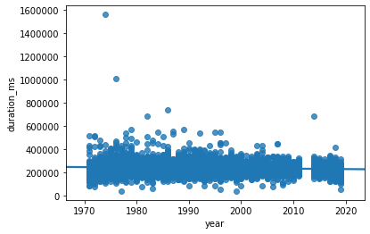

```python
sns.regplot(x=data['year'],y=data['duration_ms'])
```

Here we plot rank and song length, and again we find a minimal relationship.

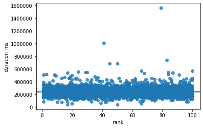

```python
sns.regplot(x=data['rank'],y=data['duration_ms'])
```

Here we plot acousticness over time. Though it is messy, there is a slight relationship. Later, we will see more clearly.

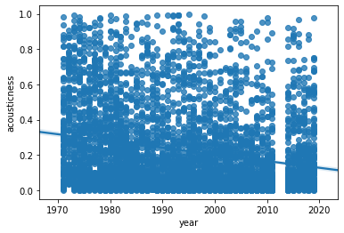

```python
sns.regplot(x=data['year'],y=data['acousticness'])
```

Here we graph speechiness over time, and see that again there is a somewhat unclear but present relationship.

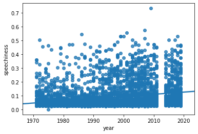

```python
sns.regplot(x=data['year'],y=data['speechiness'])
```

Obviously the sheer volume of datapoints is overwhelming and making it hard to find relationships. To help with this, we will average every value for each year:

```python
grouped = data.groupby('year',as_index = False).mean()
grouped.head()
```

|  | year | rank | danceability | energy | key | loudness | mode | speechiness | acousticness | instrumentalness | liveness | valence | tempo | duration_ms | time_signature |
| --- | --- | --- | --- | --- | --- | --- | --- | --- | --- | --- | --- | --- | --- | --- | --- |
| 0 | 1971 | 50.918367 | 0.585490 | 0.585415 | 4.806122 | -9.695684 | 0.714286 | 0.064344 | 0.331709 | 0.035202 | 0.156188 | 0.656673 | 116.031173 | 206402.479592 | 3.94898 |
| 1 | 1972 | 50.500000 | 0.587790 | 0.548344 | 5.200000 | -9.702650 | 0.740000 | 0.066357 | 0.401229 | 0.038205 | 0.182693 | 0.627022 | 121.754910 | 216849.780000 | 3.94000 |
| 2 | 1973 | 50.500000 | 0.600591 | 0.576703 | 5.280000 | -10.017580 | 0.700000 | 0.061200 | 0.343584 | 0.057322 | 0.174489 | 0.676807 | 121.062880 | 230446.630000 | 3.95000 |
| 3 | 1974 | 50.500000 | 0.590550 | 0.593680 | 5.120000 | -9.403870 | 0.830000 | 0.062343 | 0.348557 | 0.016483 | 0.195966 | 0.602665 | 116.840310 | 237011.880000 | 3.90000 |
| 4 | 1975 | 50.500000 | 0.604970 | 0.579202 | 5.250000 | -9.710470 | 0.800000 | 0.059326 | 0.309382 | 0.032832 | 0.192812 | 0.624714 | 113.982830 | 229086.440000 | 3.91000 |

Here we re-graph speechiness over time, and we can now clearly see that there is a positive relationship between the two. This means that songs have become more vocal as years have passed.

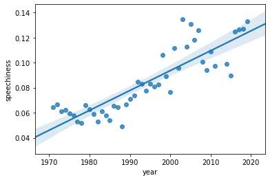

```python
sns.regplot(x=grouped['year'] , y = grouped['speechiness'])
```

If we graph acousticness and year again, we can clearly see that music has become more electrically amplified as time has passed.

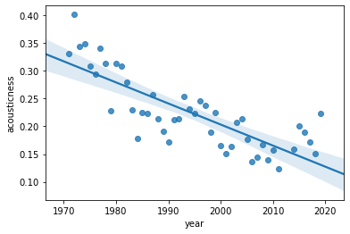

```python
sns.regplot(x=grouped['year'], y= grouped['acousticness'])
```

Here we graph average duration with year. As you can see, song lengths continued to grow from 1970 till the 1990s where they peaked. However, in the 90s they started to decrease fast and this can be seen in popular music today. The average length of a song in the top 100 in 2019 was under 200 seconds for the first time in its history. For example, the top song of 2019 Old Town Road came in at 190 seconds and its remix was only 30 seconds longer.